# Notebook

### 5. Extract from the data the interarrivals of each user's individual keystrokes. Analyze these collectively (pooling them across all users).

Again we'll look at the distribution of interarrival times.

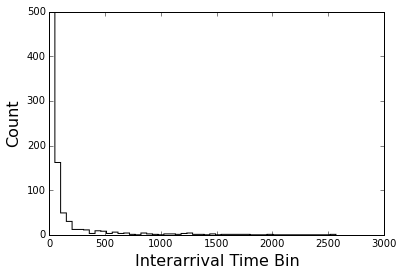

```python
interarrivals_by_user = { user: compute_interarrivals(timestamps)
                             for (user, timestamps) in keystrokes_by_user.iteritems()}
pooled_interarrivals = []
for (user, interarrivals) in interarrivals_by_user.iteritems():
    pooled_interarrivals += interarrivals
pooled_interarrivals.sort()
pooled_interarrivals = np.array(pooled_interarrivals)

_, _, _ = plot_interarrival_histogram(pooled_interarrivals, ymax=500)
```

There are so many interarrival times in the very low levels that this graph can't really show this effectively. (Using a log scale y-axis doesn't really work given zero or lower y values. Increasing the y-axis limit makes the values in higher bins invisible.)

```
Lambda: 0.528413
```

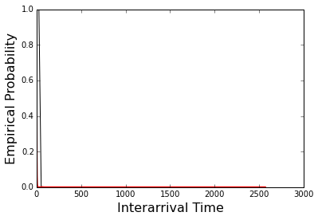

```python
plot_interarrival_empirical_pdf(pooled_interarrivals, ymax=1.)
```

This is really impossible to read and looks kind of wrong. Let's try a CDF instead.

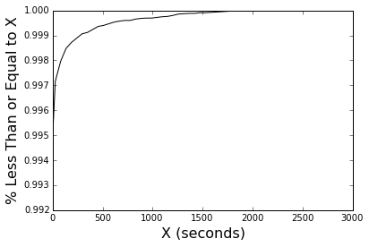

```python
import scipy.stats

def plot_cdf(seq):
    hist, l, b, e = scipy.stats.cumfreq(seq, 50)
    plt.plot(np.linspace(l, l+(b*50), 50), hist/len(seq), color='black')
    plt.xlim(xmin=0)
    plt.xlabel("X (seconds)", fontsize=16)
    plt.ylabel("% Less Than or Equal to X", fontsize=16)

plot_cdf(pooled_interarrivals)
```

Note the y-axis. If we started at zero you wouldn't be able to see any line because it hugs the corners so tightly. 99.6% of the data appears to be very close to 1. For some reason making the x-axis log-scale doesn't render properly. Let's look more carefully.

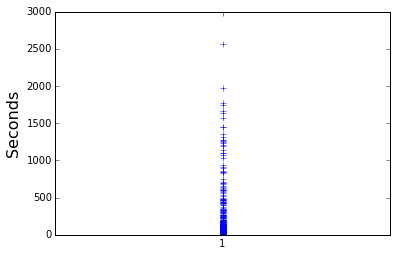

```python
plt.boxplot(pooled_interarrivals)
_ = plt.ylabel("Seconds", fontsize=16)
```

This looks terrible too, all you can see are the outliers. Let's try to remove those. We will use [Tukey and Hoaglin's definition of quartiles](http://mathworld.wolfram.com/Quartile.html) and remove all [points that lie 1.5 times the interquartile range beyond the first or third quartile](http://mathworld.wolfram.com/Outlier.html).

```python
n = len(pooled_interarrivals)
k = 2 if n % 2 == 0 else 1
first_quartile_idx = (n + k + 1)/4
first_quartile = pooled_interarrivals[first_quartile_idx]
third_quartile_idx = (3*n + k)/4
third_quartile = pooled_interarrivals[third_quartile_idx]
iqr = third_quartile - first_quartile

low = pooled_interarrivals < first_quartile - 1.5*iqr
high = pooled_interarrivals > third_quartile + 1.5*iqr
low_outliers = np.extract(low, pooled_interarrivals)
high_outliers = np.extract(high, pooled_interarrivals)
neither = np.logical_and(np.logical_not(low), np.logical_not(high))
not_outliers = np.extract(neither, pooled_interarrivals)

print "First quartile index: %d" % first_quartile_idx
print "First quartile value: %f" % first_quartile
print "Third quartile index: %d" % third_quartile_idx
print "Third quartile value: %f" % third_quartile
print "Interquartile range: %f" % iqr
print "Number of high outliers: %d" % len(high_outliers)
print "Number of low outliers: %d" % len(low_outliers)
print "Total outliers: %d" % (len(low_outliers) + len(high_outliers))
print "Percent outliers: %.2f" % ((len(low_outliers) + len(high_outliers))*1./n*100.)
```

```
First quartile index: 18658
First quartile value: 0.103951
Third quartile index: 55975
Third quartile value: 0.358921
Interquartile range: 0.254970
Number of high outliers: 10320
Number of low outliers: 0
Total outliers: 10320
Percent outliers: 13.83
```

This seems extreme but we'll try it.

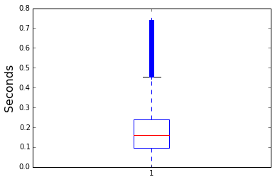

```python
plt.boxplot(not_outliers)
_ = plt.ylabel("Seconds", fontsize=16)
```

There appear to be some new outliers but at least this is legible.

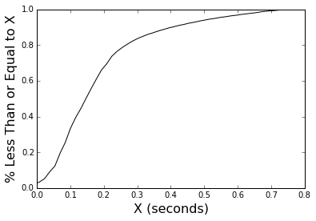

```python
plot_cdf(not_outliers)
```

### 6. The aggregate set of interarrivals that you extracted has more than one qualitatively different type of behavior. See to what degree you can identify these, and explain how you did so.

As noted before, it appears that there are a number of outliers on the high side, and that most interarrival times are in the subsecond range. This is apparent from the CDF's above. Here are some more numbers on that:

```python
def print_pct_in_interval(seq, low=None, high=None):
    n = len(seq)
    if low is None and high is None:
        return 100.
    if low is not None:
        high_enough = seq > float(low)
        condition = high_enough
    if high is not None:
        low_enough = seq <= float(high)
        condition = low_enough
    if low is not None and high is not None:
        condition = np.logical_and(low_enough, high_enough)
    interval = np.extract(condition, seq)
    pct = len(interval)*1./n*100
    low = "0" if low is None else str(low)
    high = "0" if high is None else str(high)
    print "Percent in interval (%4s, %4s]: \t%.2f" % (low, high, pct)

print "Percent of all the data in various intervals:"
print_pct_in_interval(pooled_interarrivals, high=.01)
print_pct_in_interval(pooled_interarrivals, high=.1)
print_pct_in_interval(pooled_interarrivals, high=.25)
print_pct_in_interval(pooled_interarrivals, high=.5)
print_pct_in_interval(pooled_interarrivals, high=.75)
print_pct_in_interval(pooled_interarrivals, high=1)
print_pct_in_interval(pooled_interarrivals, high=10)
print_pct_in_interval(pooled_interarrivals, high=60)
print_pct_in_interval(pooled_interarrivals, high=300)
print_pct_in_interval(pooled_interarrivals, low=.1, high=.5) # Normal typing rate?
print
print "Percent of data with outliers removed:"
print_pct_in_interval(not_outliers, high=.3)
```

```
Percent of all the data in various intervals:
Percent in interval (   0, 0.01]: 	2.13
Percent in interval (   0,  0.1]: 	22.78
Percent in interval (   0, 0.25]: 	65.98
Percent in interval (   0,  0.5]: 	80.78
Percent in interval (   0, 0.75]: 	86.35
Percent in interval (   0,    1]: 	89.33
Percent in interval (   0,   10]: 	98.37
Percent in interval (   0,   60]: 	99.62
Percent in interval (   0,  300]: 	99.89
Percent in interval ( 0.1,  0.5]: 	58.00

Percent of data with outliers removed:
Percent in interval (   0,  0.3]: 	82.63
```

### 7. Similar to the above regarding the arrival of users, some theories presume that the arrival of an individual user's keystrokes likewise looks like a Poisson process. Based on the aggregate interarrivals of user keystrokes that you extracted above, explore (to the degree that you can) whether you believe that this data supports that premise. Explain how you arrived at your conclusion.

Similar to the above, we'll look at the distribution of the interarrivals with outliers removed and then compute Grubb's test statistic.

```
Lambda: 5.089009
```

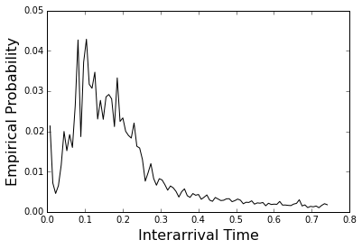

```python
plot_interarrival_empirical_pdf(not_outliers, ymax=.05)
```

I've had a lot of trouble with the above graph -- something is wrong with how I am computing EPDFs. At any rate, computing the test statistic, I found:

```python
print "With outliers:"
is_exponential_based_on_grubbs(pooled_interarrivals)
print "\nWithout outliers:"
_ = is_exponential_based_on_grubbs(not_outliers)
```

```
With outliers:
Grubbs's test statistic: 0.06144
Test 0.39894:
Follows an exponential distribution: False

Without outliers:
Grubbs's test statistic: 1.32293
Test 0.39894:
Follows an exponential distribution: True
```

### 8. I've added an artificial artifact to the data that manifests when analyzing the interarrivals of individual user keystrokes. (This is based on a true quirk that occurs in other such keystroke datasets, though didn't happen to do so for this one.) See if you can spot it. If so, explain how you found it, and whether you also find any evidence that it's synthetic rather than arising from actual user activity.

I'm guessing this is the "user250" issue caught above, where user250 had an event every minute on the minute:

```python
print [(t - first_timestamp)/60. for t in keystrokes_by_user["user250"]]
```

```
[0.014003129800160725, 1.0065730492273965, 2.0130516489346824, 3.0133073329925537, 4.015194114049276, 5.003292512893677, 6.005587049325308, 7.012803832689921, 8.00462958017985, 9.009232831001281, 10.007956616083781, 11.010481182734171, 12.006079749266307, 13.008556679884594, 14.015870499610902, 15.0…
```

### 10. How much time did you spend on this assignment?

About 4-5 hours. There was some overhead involved in: * installing Mavericks so I could upgrade matplotlib, * uninstaling and reinstalling other software, * filing bug reports for matplotlib from bugs that I found, and * getting up to speed with IPython. So it is hard to estimate the time this assignment required accurately.

### 11. What additional data or meta-data did you find you wished this dataset had included (if any)?

I didn't find any additional metadata. I didn't really feel that additional metadata would have been helpful without breaching privacy. It would be nice to know what year this data set is from and what the primary high-level activity users were performing (i.e., what the machine is primarily used for).

### 12. (Optional:) Any comments on the assignment? Was it illuminating/frustrating/fun/boring? What would improve it?

It was fun! Finding bugs in matplotlib has not been fun though. One change I would have made is to make the first question more specific because I ended up answering almost all the questions through the graphs I made for the first question.